# CreditCard Users Churn Prediction

### Notes from models

- gradient boost had the best recall out of all the models
- there are 2 outliers on xg boost and 1 outlier on adaboost

### Logistic regression tuning

```python
### Oversampling the data

from imblearn.over_sampling import SMOTE

print("Before UpSampling, counts of label 'Yes': {}".format(sum(y_train==1)))
print("Before UpSampling, counts of label 'No': {} \n".format(sum(y_train==0)))

sm = SMOTE(sampling_strategy = 1 ,k_neighbors = 5, random_state=1)   #Synthetic Minority Over Sampling Technique
X_train_over, y_train_over = sm.fit_resample(X_train, y_train)


print("After UpSampling, counts of label 'Yes': {}".format(sum(y_train_over==1)))
print("After UpSampling, counts of label 'No': {} \n".format(sum(y_train_over==0)))


print('After UpSampling, the shape of train_X: {}'.format(X_train_over.shape))
print('After UpSampling, the shape of train_y: {} \n'.format(y_train_over.shape))
```

```
Before UpSampling, counts of label 'Yes': 5949
Before UpSampling, counts of label 'No': 1139

After UpSampling, counts of label 'Yes': 5949
After UpSampling, counts of label 'No': 5949

After UpSampling, the shape of train_X: (11898, 18)
After UpSampling, the shape of train_y: (11898,)
```

```python
log_reg_over = LogisticRegression(random_state = 1)

# Training the basic logistic regression model with training set
log_reg_over.fit(X_train_over,y_train_over)
```

```
LogisticRegression(random_state=1)
```

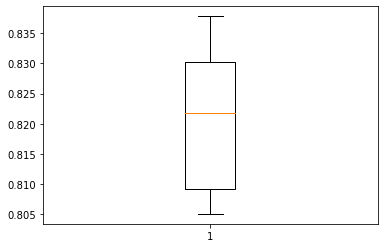

```python
scoring='recall'
kfold=StratifiedKFold(n_splits=5,shuffle=True,random_state=1)     #Setting number of splits equal to 5
cv_result_over=cross_val_score(estimator=log_reg_over, X=X_train_over, y=y_train_over, scoring=scoring, cv=kfold)
#Plotting boxplots for CV scores of model defined above
plt.boxplot(cv_result_over)
plt.show()
```

```
Accuracy on training set :  0.8212471783295711
Accuracy on test set :  0.813754524514643
Recall on training set :  0.8271978483778787
Recall on test set :  0.822422579380635
Precision on training set :  0.9536821705426357
Precision on test set :  0.9488919041157847
```

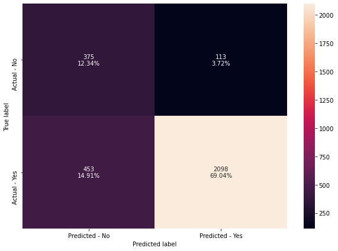

```python
#Calculating different metrics
get_metrics_score(log_reg_over)

# creating confusion matrix
make_confusion_matrix(log_reg_over,y_test)
```

#### Notes on oversampling

- recall has decreased from the regular logistic regression

```python
##Regularization

# Choose the type of classifier.
lr_estimator_reg = LogisticRegression(random_state=1,solver='saga')

# Grid of parameters to choose from
parameters = {'C': np.arange(0.1,1.1,0.1)}

# Run the grid search
grid_obj = GridSearchCV(lr_estimator_reg, parameters, scoring='recall')
grid_obj = grid_obj.fit(X_train_over, y_train_over)

# Set the clf to the best combination of parameters
lr_estimator_reg = grid_obj.best_estimator_

# Fit the best algorithm to the data.
lr_estimator_reg.fit(X_train_over, y_train_over)
```

```
LogisticRegression(C=0.1, random_state=1, solver='saga')
```

```
Accuracy on training set :  0.7904909706546276
Accuracy on test set :  0.7903915761763738
Recall on training set :  0.8285426122037317
Recall on test set :  0.8330066640533125
Precision on training set :  0.9137931034482759
Precision on test set :  0.9096746575342466
```

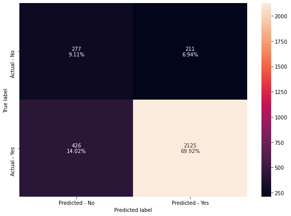

```python
#Calculating different metrics
get_metrics_score(lr_estimator_reg)

# creating confusion matrix
make_confusion_matrix(lr_estimator_reg,y_test)
```

#### Notes on regularization

- regularization-based recall has increased from oversampling

```python
#### Undersampling data

from imblearn.under_sampling import RandomUnderSampler
rus = RandomUnderSampler(random_state = 1)
X_train_un, y_train_un = rus.fit_resample(X_train, y_train)
```

```python
print("Before Under Sampling, counts of label 'Yes': {}".format(sum(y_train==1)))
print("Before Under Sampling, counts of label 'No': {} \n".format(sum(y_train==0)))

print("After Under Sampling, counts of label 'Yes': {}".format(sum(y_train_un==1)))
print("After Under Sampling, counts of label 'No': {} \n".format(sum(y_train_un==0)))

print('After Under Sampling, the shape of train_X: {}'.format(X_train_un.shape))
print('After Under Sampling, the shape of train_y: {} \n'.format(y_train_un.shape))
```

```
Before Under Sampling, counts of label 'Yes': 5949
Before Under Sampling, counts of label 'No': 1139

After Under Sampling, counts of label 'Yes': 1139
After Under Sampling, counts of label 'No': 1139

After Under Sampling, the shape of train_X: (2278, 18)
After Under Sampling, the shape of train_y: (2278,)
```

```python
log_reg_under = LogisticRegression(random_state = 1)
log_reg_under.fit(X_train_un,y_train_un )
```

```
LogisticRegression(random_state=1)
```

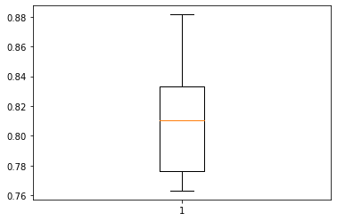

```python
scoring='recall'
kfold=StratifiedKFold(n_splits=5,shuffle=True,random_state=1)     #Setting number of splits equal to 5
cv_result_under=cross_val_score(estimator=log_reg_under, X=X_train_un, y=y_train_un, scoring=scoring, cv=kfold)
#Plotting boxplots for CV scores of model defined above
plt.boxplot(cv_result_under)
plt.show()
```

```
Accuracy on training set :  0.8129232505643341
Accuracy on test set :  0.8134254689042448
Recall on training set :  0.8221549840309296
Recall on test set :  0.8275186201489612
Precision on training set :  0.948051948051948
Precision on test set :  0.9432529043789097
```

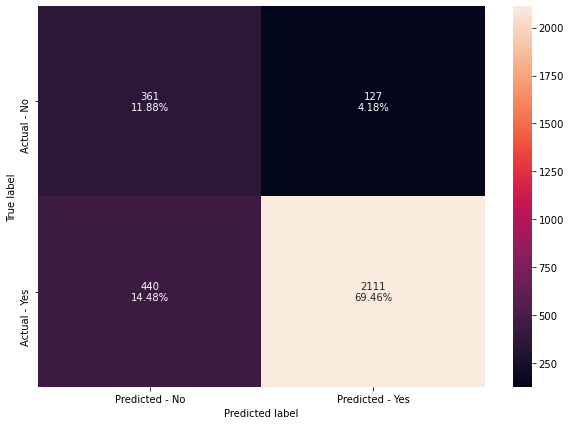

```python
#Calculating different metrics
get_metrics_score(log_reg_under)


# creating confusion matrix
make_confusion_matrix(log_reg_under,y_test)
```

#### Notes from under sampling:

- recall is not as good as it was originally, and also not as good as regularization

#### Decision tree tuning

```python
### Bagging

#base_estimator for bagging classifier is a decision tree by default
bagging_estimator=BaggingClassifier(random_state=3)
bagging_estimator.fit(X_train,y_train)
```

```
BaggingClassifier(random_state=3)
```

```
Accuracy on training set :  0.9973194130925508
Accuracy on test set :  0.9486673247778875
Recall on training set :  0.9978147587829888
Recall on test set :  0.969031752254018
Precision on training set :  0.9989902389767755
Precision on test set :  0.9697920753236563
```

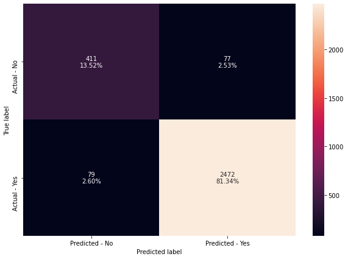

```python
#Using above defined function to get accuracy, recall and precision on train and test set
bagging_estimator_score=get_metrics_score(bagging_estimator)

# creating confusion matrix
make_confusion_matrix(bagging_estimator,y_test)
```

#### Insights from bagging

- recall is a little bit better than base decision tree

```python
#### tuned bagging

#Tune the decision tree
dtree_estimator = DecisionTreeClassifier(class_weight={0:0.18,1:0.72},random_state=1)

# Grid of parameters to choose from
parameters = {'max_depth': np.arange(2,30),
              'min_samples_leaf': [1, 2, 5, 7],
              'max_leaf_nodes' : [2, 3, 5, 10],
              'min_impurity_decrease': [0.001,0.01,0.1]
             }

# Type of scoring used to compare parameter combinations
scorer = metrics.make_scorer(metrics.f1_score)

# Run the grid search
grid_obj = GridSearchCV(dtree_estimator, parameters, scoring=scorer,n_jobs=1)
grid_obj = grid_obj.fit(X_train, y_train)

# Set the clf to the best combination of parameters
dtree_estimator = grid_obj.best_estimator_

# Fit the best algorithm to the data.
dtree_estimator.fit(X_train, y_train)
```

```
DecisionTreeClassifier(class_weight={0: 0.18, 1: 0.72}, max_depth=6,
                       max_leaf_nodes=10, min_impurity_decrease=0.001,
                       random_state=1)
```

```
Accuracy on training set :  0.9119638826185101
Accuracy on test set :  0.9029285949325436
Recall on training set :  0.9959657085224407
Recall on test set :  0.9956879655037241
Precision on training set :  0.9080459770114943
Precision on test set :  0.8994334277620396
```

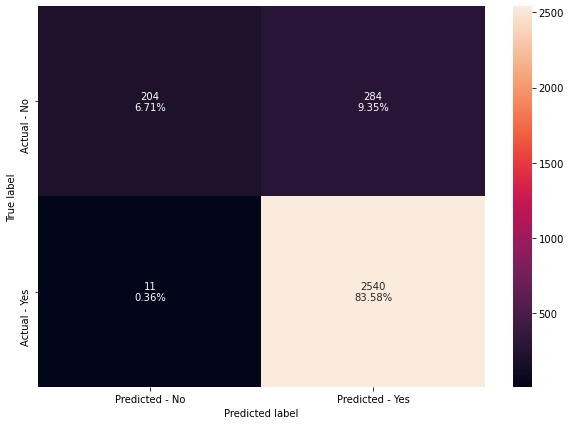

```python
dtree_tuned = get_metrics_score(dtree_estimator)

make_confusion_matrix(dtree_estimator,y_test)
```

### Notes on tuned bagging

#### Adaboost hyperparameter tuning with Grid Search CV

```python
%%time

# Creating pipeline
pipe = make_pipeline(StandardScaler(), AdaBoostClassifier(random_state=1))

# Parameter grid to pass in GridSearchCV
param_grid = {
    "adaboostclassifier__n_estimators": np.arange(10, 110, 10),
    "adaboostclassifier__learning_rate": [0.1, 0.01, 0.2, 0.05, 1],
    "adaboostclassifier__base_estimator": [
        DecisionTreeClassifier(max_depth=1, random_state=1),
        DecisionTreeClassifier(max_depth=2, random_state=1),
        DecisionTreeClassifier(max_depth=3, random_state=1),
    ],
}

# Type of scoring used to compare parameter combinations
scorer = metrics.make_scorer(metrics.recall_score)

# Calling GridSearchCV
grid_cv = GridSearchCV(estimator=pipe, param_grid=param_grid, scoring=scorer, cv=5, n_jobs = -1)

# Fitting parameters in GridSeachCV
grid_cv.fit(X_train, y_train)

print(
    "Best Parameters:{} \nScore: {}".format(grid_cv.best_params_, grid_cv.best_score_)
)
```

```
Best Parameters:{'adaboostclassifier__base_estimator': DecisionTreeClassifier(max_depth=1, random_state=1), 'adaboostclassifier__learning_rate': 0.1, 'adaboostclassifier__n_estimators': 10}
Score: 1.0
CPU times: user 2.71 s, sys: 470 ms, total: 3.18 s
Wall time: 1min 50s
```

```python
### Creating new pipeline with best parameters
abc_tuned_grid = make_pipeline(
    StandardScaler(),
    AdaBoostClassifier(
        base_estimator=DecisionTreeClassifier(max_depth=2, random_state=1),
        n_estimators=100,
        learning_rate=1,
        random_state=1,),)

# Fit the model on training data
abc_tuned_grid.fit(X_train, y_train)
```

```
Pipeline(steps=[('standardscaler', StandardScaler()),
                ('adaboostclassifier',
                 AdaBoostClassifier(base_estimator=DecisionTreeClassifier(max_depth=2,
                                                                          random_state=1),
                                    learning_rate=1, n_estimators=100,
                                    random_state=1))])
```

```
Accuracy on training set :  0.9976015801354402
Accuracy on test set :  0.9657782165185916
Recall on training set :  0.9983190452176837
Recall on test set :  0.9870638965111721
Precision on training set :  0.9988227379751093
Precision on test set :  0.9725762842796446
```

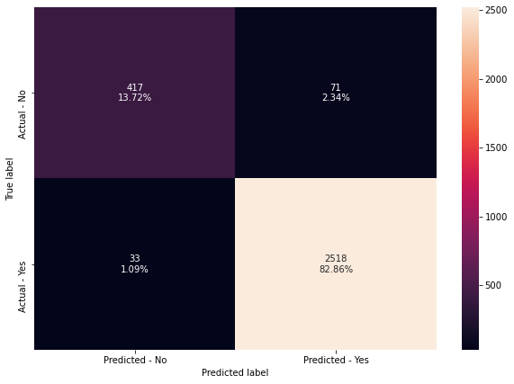

```python
# Calculating different metrics
get_metrics_score(abc_tuned_grid)

# Creating confusion matrix
make_confusion_matrix(abc_tuned_grid, y_test)
```

#### Notes from tuned adaboost

- recall has increased to 99% on the grid search tuned adaboost

#### Randomized search on adaboost

```python
%%time

# Creating pipeline
pipe = make_pipeline(StandardScaler(), AdaBoostClassifier(random_state=1))

# Parameter grid to pass in RandomizedSearchCV
param_grid = {
    "adaboostclassifier__n_estimators": np.arange(10, 110, 10),
    "adaboostclassifier__learning_rate": [0.1, 0.01, 0.2, 0.05, 1],
    "adaboostclassifier__base_estimator": [
        DecisionTreeClassifier(max_depth=1, random_state=1),
        DecisionTreeClassifier(max_depth=2, random_state=1),
        DecisionTreeClassifier(max_depth=3, random_state=1),
    ],
}
# Type of scoring used to compare parameter combinations
scorer = metrics.make_scorer(metrics.recall_score)

#Calling RandomizedSearchCV
abc_tuned_rand = RandomizedSearchCV(estimator=pipe, param_distributions=param_grid, n_iter=25, scoring=scorer, cv=2, random_state=1)

#Fitting parameters in RandomizedSearchCV
abc_tuned_rand.fit(X_train,y_train)

print("Best parameters are {} with CV score={}:" .format(abc_tuned_rand.best_params_,abc_tuned_rand.best_score_))
```

```
Best parameters are {'adaboostclassifier__n_estimators': 50, 'adaboostclassifier__learning_rate': 0.01, 'adaboostclassifier__base_estimator': DecisionTreeClassifier(max_depth=1, random_state=1)} with CV score=1.0:
CPU times: user 15.8 s, sys: 216 ms, total: 16.1 s
Wall time: 16.3 s
```

```python
# Creating new pipeline with best parameters
abc_tuned_rand = make_pipeline(
    StandardScaler(),
    AdaBoostClassifier(
        base_estimator=DecisionTreeClassifier(max_depth=2, random_state=1),
        n_estimators=100,
        learning_rate=1,
        random_state=1,
    ),
)

# Fit the model on training data
abc_tuned_rand.fit(X_train, y_train)
```

```
Pipeline(steps=[('standardscaler', StandardScaler()),
                ('adaboostclassifier',
                 AdaBoostClassifier(base_estimator=DecisionTreeClassifier(max_depth=2,
                                                                          random_state=1),
                                    learning_rate=1, n_estimators=100,
                                    random_state=1))])
```

```
Accuracy on training set :  0.9976015801354402
Accuracy on test set :  0.9657782165185916
Recall on training set :  0.9983190452176837
Recall on test set :  0.9870638965111721
Precision on training set :  0.9988227379751093
Precision on test set :  0.9725762842796446
```

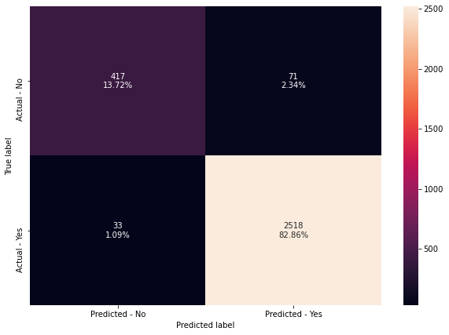

```python
# Calculating different metrics
get_metrics_score(abc_tuned_rand)

# Creating confusion matrix
make_confusion_matrix(abc_tuned_rand, y_test)
```

#### Notes on tuned adaboost using randomized CV

- recall has stayed the same, at 98%, which is pretty good
- grid search cv took more time than randomized search cv for adaboost

#### Grid search CV on GBM

```python
%%time

#Creating pipeline
pipe=make_pipeline(StandardScaler(), GradientBoostingClassifier(random_state=1))

parameters = {
    "learning_rate": [0.01, 0.075, 0.1, 0.2],
    "min_samples_split": np.linspace(0.1, 0.5, 12),
    "min_samples_leaf": np.linspace(0.1, 0.5, 12),
    "max_depth":[3,5,8]
    }
#passing the scoring function in the GridSearchCV
gbm_tuned_grid = GridSearchCV(GradientBoostingClassifier(), parameters,scoring=scoring,refit=True,cv=2, n_jobs=1)

gbm_tuned_grid.fit(X_train, y_train)
```

```
CPU times: user 23min 37s, sys: 11.1 s, total: 23min 49s
Wall time: 24min 13s
```

```
GridSearchCV(cv=2, estimator=GradientBoostingClassifier(), n_jobs=1,
             param_grid={'learning_rate': [0.01, 0.075, 0.1, 0.2],
                         'max_depth': [3, 5, 8],
                         'min_samples_leaf': array([0.1       , 0.13636364, 0.17272727, 0.20909091, 0.24545455,
       0.28181818, 0.31818182, 0.35454545, 0.39090909, 0.42727273,
       0.46363636, 0.5       ]),
                         'min_samples_split': array([0.1       , 0.13636364, 0.17272727, 0.20909091, 0.24545455,
       0.28181818, 0.31818182, 0.35454545, 0.39090909, 0.42727273,
       0.46363636, 0.5       ])},
             scoring='recall')
```

```python
# Creating new pipeline with best parameters
gbm_tuned_grid = make_pipeline(
    StandardScaler(),
    GradientBoostingClassifier(
        n_estimators=100,
        learning_rate=1,
        random_state=1,
    ),
)

# Fit the model on training data
gbm_tuned_grid.fit(X_train, y_train)
```

```
Pipeline(steps=[('standardscaler', StandardScaler()),
                ('gradientboostingclassifier',
                 GradientBoostingClassifier(learning_rate=1, random_state=1))])
```

```
Accuracy on training set :  0.993510158013544
Accuracy on test set :  0.9545903257650543
Recall on training set :  0.9942847537401244
Recall on test set :  0.9721677773422187
Precision on training set :  0.9979753669647377
Precision on test set :  0.9736945425991362
```

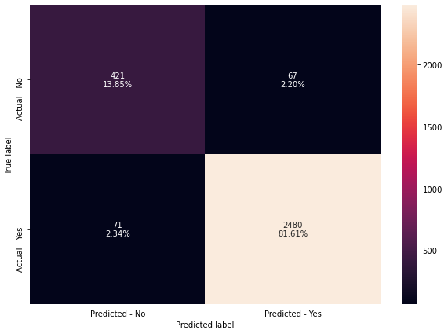

```python
# Calculating different metrics
get_metrics_score(gbm_tuned_grid)

# Creating confusion matrix
make_confusion_matrix(gbm_tuned_grid, y_test)
```